# Tarea_Comparacioón_Muestras

Mia Wayar

2025-10-16

# Librerias

```r
library(dplyr)
```

```r
library(ggplot2)
```

# Lectura de datos

```r
#Archivo Kaggle - vgsales
vgventas <- read.csv("vgsales.csv",
                 stringsAsFactors = F,na.strings = ".",header = T,sep=",")
head(vgventas)
```

```
##   Rank                     Name Platform Year        Genre Publisher NA_Sales
## 1    1               Wii Sports      Wii 2006       Sports  Nintendo    41.49
## 2    2        Super Mario Bros.      NES 1985     Platform  Nintendo    29.08
## 3    3           Mario Kart Wii      Wii 2008       Racing  Nintendo    15.85
## 4    4        Wii Sports Resort      Wii 2009       Sports  Nintendo    15.75
## 5    5 Pokemon Red/Pokemon Blue       GB 1996 Role-Playing  Nintendo    11.27
## 6    6                   Tetris       GB 1989       Puzzle  Nintendo    23.20
##   EU_Sales JP_Sales Other_Sales Global_Sales
## 1    29.02     3.77        8.46        82.74
## 2     3.58     6.81        0.77        40.24
## 3    12.88     3.79        3.31        35.82
## 4    11.01     3.28        2.96        33.00
## 5     8.89    10.22        1.00        31.37
## 6     2.26     4.22        0.58        30.26
```

```r
str(vgventas)
```

```
## 'data.frame':    16598 obs. of  11 variables:
##  $ Rank        : int  1 2 3 4 5 6 7 8 9 10 ...
##  $ Name        : chr  "Wii Sports" "Super Mario Bros." "Mario Kart Wii" "Wii Sports Resort" ...
##  $ Platform    : chr  "Wii" "NES" "Wii" "Wii" ...
##  $ Year        : chr  "2006" "1985" "2008" "2009" ...
##  $ Genre       : chr  "Sports" "Platform" "Racing" "Sports" ...
##  $ Publisher   : chr  "Nintendo" "Nintendo" "Nintendo" "Nintendo" ...
##  $ NA_Sales    : num  41.5 29.1 15.8 15.8 11.3 ...
##  $ EU_Sales    : num  29.02 3.58 12.88 11.01 8.89 ...
##  $ JP_Sales    : num  3.77 6.81 3.79 3.28 10.22 ...
##  $ Other_Sales : num  8.46 0.77 3.31 2.96 1 0.58 2.9 2.85 2.26 0.47 ...
##  $ Global_Sales: num  82.7 40.2 35.8 33 31.4 ...
```

# Transformacion de los datos

```r
vgventas$Year <- as.integer(vgventas$Year)
vgventas$Genre <- as.factor(vgventas$Genre)
vgventas$Platform <- as.factor(vgventas$Platform)
vgventas$Publisher <- as.factor(vgventas$Publisher)
summary(vgventas)
```

```
##       Rank           Name              Platform         Year
##  Min.   :    1   Length:16598       DS     :2163   Min.   :1980
##  1st Qu.: 4151   Class :character   PS2    :2161   1st Qu.:2003
##  Median : 8300   Mode  :character   PS3    :1329   Median :2007
##  Mean   : 8301                      Wii    :1325   Mean   :2006
##  3rd Qu.:12450                      X360   :1265   3rd Qu.:2010
##  Max.   :16600                      PSP    :1213   Max.   :2020
##                                     (Other):7142   NA's   :271
##           Genre                             Publisher        NA_Sales
##  Action      :3316   Electronic Arts             : 1351   Min.   : 0.0000
##  Sports      :2346   Activision                  :  975   1st Qu.: 0.0000
##  Misc        :1739   Namco Bandai Games          :  932   Median : 0.0800
##  Role-Playing:1488   Ubisoft                     :  921   Mean   : 0.2647
##  Shooter     :1310   Konami Digital Entertainment:  832   3rd Qu.: 0.2400
##  Adventure   :1286   THQ                         :  715   Max.   :41.4900
##  (Other)     :5113   (Other)                     :10872
##     EU_Sales          JP_Sales         Other_Sales        Global_Sales
##  Min.   : 0.0000   Min.   : 0.00000   Min.   : 0.00000   Min.   : 0.0100
##  1st Qu.: 0.0000   1st Qu.: 0.00000   1st Qu.: 0.00000   1st Qu.: 0.0600
##  Median : 0.0200   Median : 0.00000   Median : 0.01000   Median : 0.1700
##  Mean   : 0.1467   Mean   : 0.07778   Mean   : 0.04806   Mean   : 0.5374
##  3rd Qu.: 0.1100   3rd Qu.: 0.04000   3rd Qu.: 0.04000   3rd Qu.: 0.4700
##  Max.   :29.0200   Max.   :10.22000   Max.   :10.57000   Max.   :82.7400
##
```

Calculemos la proporcion de los datos missings Esto nos ayudará a decidir la estrategia (borrar vs. llenar)

```r
# Contar NA por columna
na_por_columna <- colSums(is.na(vgventas))
print("NA por columna:")
```

```
## [1] "NA por columna:"
```

```r
print(na_por_columna)
```

```
##         Rank         Name     Platform         Year        Genre    Publisher
##            0            0            0          271            0            0
##     NA_Sales     EU_Sales     JP_Sales  Other_Sales Global_Sales
##            0            0            0            0            0
```

```r
# Porcentaje de NA por columna
porcentaje_na <- colMeans(is.na(vgventas)) * 100
print("Porcentaje de NA por columna:")
```

```
## [1] "Porcentaje de NA por columna:"
```

```r
print(round(porcentaje_na, 2))
```

```
##         Rank         Name     Platform         Year        Genre    Publisher
##         0.00         0.00         0.00         1.63         0.00         0.00
##     NA_Sales     EU_Sales     JP_Sales  Other_Sales Global_Sales
##         0.00         0.00         0.00         0.00         0.00
```

```r
unique(vgventas$Publisher)
```

```
##   [1] Nintendo
##   [2] Microsoft Game Studios
##   [3] Take-Two Interactive
##   [4] Sony Computer Entertainment
##   [5] Activision
##   [6] Ubisoft
##   [7] Bethesda Softworks
##   [8] Electronic Arts
##   [9] Sega
##  [10] SquareSoft
##  [11] Atari
##  [12] 505 Games
##  [13] Capcom
##  [14] GT Interactive
##  [15] Konami Digital Entertainment
```

[output cut: 565 more lines]

```r
filter(vgventas, Publisher==" ")
```

```
##  [1] Rank         Name         Platform     Year         Genre
##  [6] Publisher    NA_Sales     EU_Sales     JP_Sales     Other_Sales
## [11] Global_Sales
## <0 rows> (or 0-length row.names)
```

```r
# DataFrame de ejemplo con missing values

print("DataFrame original:")
```

```
## [1] "DataFrame original:"
```

```r
head(vgventas)
```

```
##   Rank                     Name Platform Year        Genre Publisher NA_Sales
## 1    1               Wii Sports      Wii 2006       Sports  Nintendo    41.49
## 2    2        Super Mario Bros.      NES 1985     Platform  Nintendo    29.08
## 3    3           Mario Kart Wii      Wii 2008       Racing  Nintendo    15.85
## 4    4        Wii Sports Resort      Wii 2009       Sports  Nintendo    15.75
## 5    5 Pokemon Red/Pokemon Blue       GB 1996 Role-Playing  Nintendo    11.27
## 6    6                   Tetris       GB 1989       Puzzle  Nintendo    23.20
##   EU_Sales JP_Sales Other_Sales Global_Sales
## 1    29.02     3.77        8.46        82.74
## 2     3.58     6.81        0.77        40.24
## 3    12.88     3.79        3.31        35.82
## 4    11.01     3.28        2.96        33.00
## 5     8.89    10.22        1.00        31.37
## 6     2.26     4.22        0.58        30.26
```

```r
cat("Filas originales:", nrow(vgventas), "\n\n")
```

```
## Filas originales: 16598
```

```r
# Método 1: na.omit() - Elimina filas con cualquier NA
df_sin_na <- na.omit(vgventas)
print("Con na.omit():")
```

```
## [1] "Con na.omit():"
```

```r
head(df_sin_na)
```

```
##   Rank                     Name Platform Year        Genre Publisher NA_Sales
## 1    1               Wii Sports      Wii 2006       Sports  Nintendo    41.49
## 2    2        Super Mario Bros.      NES 1985     Platform  Nintendo    29.08
## 3    3           Mario Kart Wii      Wii 2008       Racing  Nintendo    15.85
## 4    4        Wii Sports Resort      Wii 2009       Sports  Nintendo    15.75
## 5    5 Pokemon Red/Pokemon Blue       GB 1996 Role-Playing  Nintendo    11.27
## 6    6                   Tetris       GB 1989       Puzzle  Nintendo    23.20
##   EU_Sales JP_Sales Other_Sales Global_Sales
## 1    29.02     3.77        8.46        82.74
## 2     3.58     6.81        0.77        40.24
## 3    12.88     3.79        3.31        35.82
## 4    11.01     3.28        2.96        33.00
## 5     8.89    10.22        1.00        31.37
## 6     2.26     4.22        0.58        30.26
```

```r
cat("Filas después de na.omit():", nrow(df_sin_na), "\n\n")
```

```
## Filas después de na.omit(): 16327
```

```r
# Método 2: complete.cases() - Más control
df_completo <- vgventas[complete.cases(vgventas), ]
print("Con complete.cases():")
```

```
## [1] "Con complete.cases():"
```

```r
head(df_completo)
```

```
##   Rank                     Name Platform Year        Genre Publisher NA_Sales
## 1    1               Wii Sports      Wii 2006       Sports  Nintendo    41.49
## 2    2        Super Mario Bros.      NES 1985     Platform  Nintendo    29.08
## 3    3           Mario Kart Wii      Wii 2008       Racing  Nintendo    15.85
## 4    4        Wii Sports Resort      Wii 2009       Sports  Nintendo    15.75
## 5    5 Pokemon Red/Pokemon Blue       GB 1996 Role-Playing  Nintendo    11.27
## 6    6                   Tetris       GB 1989       Puzzle  Nintendo    23.20
##   EU_Sales JP_Sales Other_Sales Global_Sales
## 1    29.02     3.77        8.46        82.74
## 2     3.58     6.81        0.77        40.24
## 3    12.88     3.79        3.31        35.82
## 4    11.01     3.28        2.96        33.00
## 5     8.89    10.22        1.00        31.37
## 6     2.26     4.22        0.58        30.26
```

```r
cat("Filas después de complete.cases():", nrow(df_completo), "\n")
```

```
## Filas después de complete.cases(): 16327
```

# Filtrar por videojuegos con ventas menores a dos millones

```r
ventas <- filter(vgventas, Global_Sales<2)
summary(ventas)
```

```
##       Rank           Name              Platform         Year
##  Min.   :  853   Length:15747       DS     :2101   Min.   :1980
##  1st Qu.: 4790   Class :character   PS2    :2028   1st Qu.:2003
##  Median : 8726   Mode  :character   Wii    :1258   Median :2007
##  Mean   : 8726                      PS3    :1225   Mean   :2006
##  3rd Qu.:12662                      PSP    :1193   3rd Qu.:2010
##  Max.   :16600                      X360   :1148   Max.   :2020
##                                     (Other):6794   NA's   :261
##           Genre                             Publisher        NA_Sales
##  Action      :3140   Electronic Arts             : 1225   Min.   :0.0000
##  Sports      :2228   Namco Bandai Games          :  920   1st Qu.:0.0000
##  Misc        :1664   Activision                  :  909   Median :0.0700
##  Role-Playing:1392   Ubisoft                     :  873   Mean   :0.1558
##  Adventure   :1272   Konami Digital Entertainment:  806   3rd Qu.:0.2000
##  Shooter     :1199   THQ                         :  690   Max.   :1.9400
##  (Other)     :4852   (Other)                     :10324
##     EU_Sales          JP_Sales        Other_Sales       Global_Sales
##  Min.   :0.00000   Min.   :0.00000   Min.   :0.00000   Min.   :0.0100
##  1st Qu.:0.00000   1st Qu.:0.00000   1st Qu.:0.00000   1st Qu.:0.0600
##  Median :0.02000   Median :0.00000   Median :0.01000   Median :0.1500
##  Mean   :0.07964   Mean   :0.04934   Mean   :0.02668   Mean   :0.3118
##  3rd Qu.:0.09000   3rd Qu.:0.03000   3rd Qu.:0.03000   3rd Qu.:0.4000
##  Max.   :1.58000   Max.   :1.71000   Max.   :1.33000   Max.   :1.9900
##
```

# CREACIÓN DE LA VARIABLE Peso_NA

```r
ventas$Peso_NA <- ventas$NA_Sales / ventas$Global_Sales
poblacion_stats <- ventas %>%
  summarise(
    Media = mean(Peso_NA, na.rm = TRUE),
    Mediana = median(Peso_NA, na.rm = TRUE),
    Desviacion = sd(Peso_NA, na.rm = TRUE),
    Minimo = min(Peso_NA, na.rm = TRUE),
    Maximo = max(Peso_NA, na.rm = TRUE)
  )

poblacion_stats
```

```
##       Media Mediana Desviacion Minimo Maximo
## 1 0.4537024     0.5  0.3466132      0      1
```

# Elaborar 2 muestras aleatorias de tamaño 500, extraer sus estadísticas básicas y graficar sus distribuciones.

```r
set.seed(123)
muestra1 <- sample_n(ventas, 500)
muestra2 <- sample_n(ventas, 500)

# ESTADÍSTICAS DE CADA MUESTRA
muestra1_stats <- muestra1 %>%
  summarise(
    Media = mean(Peso_NA, na.rm = TRUE),
    Mediana = median(Peso_NA, na.rm = TRUE),
    Desviacion = sd(Peso_NA, na.rm = TRUE),
    Minimo = min(Peso_NA, na.rm = TRUE),
    Maximo = max(Peso_NA, na.rm = TRUE)
  )

muestra2_stats <- muestra2 %>%
  summarise(
    Media = mean(Peso_NA, na.rm = TRUE),
    Mediana = median(Peso_NA, na.rm = TRUE),
    Desviacion = sd(Peso_NA, na.rm = TRUE),
    Minimo = min(Peso_NA, na.rm = TRUE),
    Maximo = max(Peso_NA, na.rm = TRUE)
  )

muestra1_stats
```

```
##       Media Mediana Desviacion Minimo Maximo
## 1 0.4462067     0.5  0.3517133      0      1
```

```r
muestra2_stats
```

```
##       Media Mediana Desviacion Minimo Maximo
## 1 0.4526871     0.5  0.3381385      0      1
```

# Histograma comparativo de las muestras y población

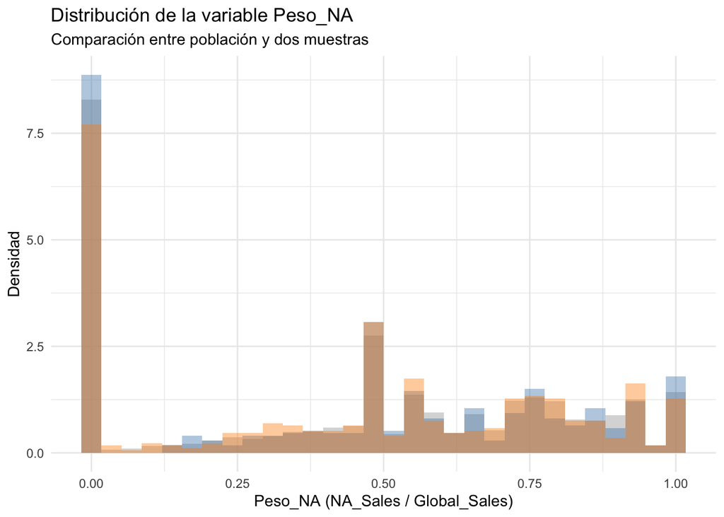

```r
ggplot() +
  geom_histogram(data = ventas, aes(x = Peso_NA, y = ..density..),
                 bins = 30, fill = "gray70", alpha = 0.5) +
  geom_histogram(data = muestra1, aes(x = Peso_NA, y = ..density..),
                 bins = 30, fill = "steelblue", alpha = 0.4) +
  geom_histogram(data = muestra2, aes(x = Peso_NA, y = ..density..),
                 bins = 30, fill = "darkorange", alpha = 0.4) +
  labs(title = "Distribución de la variable Peso_NA",
       x = "Peso_NA (NA_Sales / Global_Sales)",
       y = "Densidad",
       subtitle = "Comparación entre población y dos muestras") +
  theme_minimal()
```

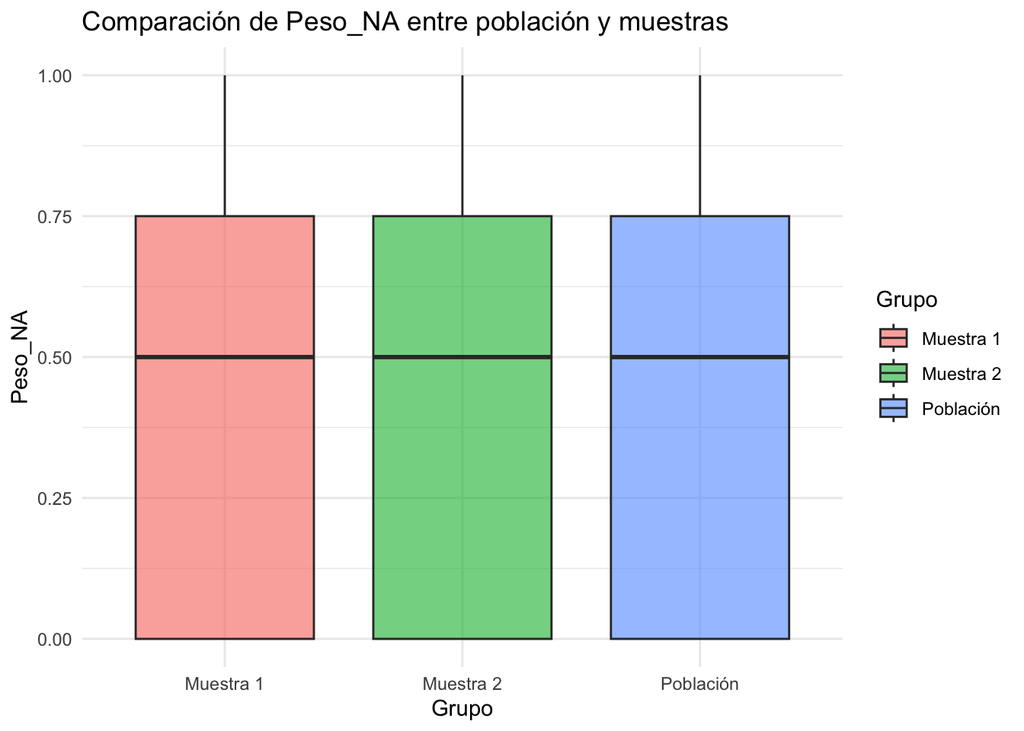

```r
# Boxplot comparativo
df_muestras <- bind_rows(
  ventas %>% mutate(Grupo = "Población"),
  muestra1 %>% mutate(Grupo = "Muestra 1"),
  muestra2 %>% mutate(Grupo = "Muestra 2")
)

ggplot(df_muestras, aes(x = Grupo, y = Peso_NA, fill = Grupo)) +
  geom_boxplot(alpha = 0.6) +
  labs(title = "Comparación de Peso_NA entre población y muestras") +
  theme_minimal()
```

```r
# COMPARACIÓN CON LA POBLACIÓN
comparacion <- rbind(
  Poblacion = poblacion_stats,
  Muestra1 = muestra1_stats,
  Muestra2 = muestra2_stats
)

comparacion
```

```
##               Media Mediana Desviacion Minimo Maximo
## Poblacion 0.4537024     0.5  0.3466132      0      1
## Muestra1  0.4462067     0.5  0.3517133      0      1
## Muestra2  0.4526871     0.5  0.3381385      0      1
```

# CONCLUSIONES Y OBSERVACIONES

Conclusiones: 1. Las medias y medianas de las muestras son similares a las de la población, lo cual sugiere que ambas son representativas. 2. Las desviaciones estándar también son parecidas, indicando variabilidad similar. 3. Las distribuciones muestran ligeras diferencias debido al muestreo aleatorio, pero mantienen una forma general consistente. 4. Como se vio en el gráfico de caja y bigotes (o bloxplot) las ventas en Norte America tanto para las dos muestras como para la problación la mediana es de 0.5, lo que indica una fuerte importancia para las empresas en videojuegos las ventas en este continente